# Working with the Child Language Data Exchange System (CHILDES) using R

Martin Schweinberger

2021-09-07

[figure not shown]

# Introduction

This workshop shows how you can use and analyze the *Child Language Data Exchange System* (CHILDES) data base using R. The RMarkdown document for the tutorial can be downloaded [here](https://slcladal.github.io/childes.Rmd) and the bib library [here](https://slcladal.github.io/bibliography.bib).

The aim of this workshop will be to introduce you to the Child Language Data Exchange System (CHILDES) data base and to show you how you can use it in your own studies.

The workshop consists of 2 parts:

1. **Introduction** on September 8: this part shows how you can access and work with CHILDES data using R.
2. **Practical issues** on September 15: this part is a practical Q&A about your own studies and things that you want me to explain so that you can do your own research.

## Prerequisites

In order to follow the content of this workshop, you should already be familiar with R/Rstudio. If you are not familiar with R/RStudio, please go through [this introduction to R/RStudio](https://slcladal.github.io/intror.html). In addition, it is recommended to be familiar with regular expressions ([this tutorials](https://slcladal.github.io/regex.html) contains an overview of regular expressions that are used in this tutorial).

You should also have downloaded and installed R and RStudio. [This tutorial](https://slcladal.github.io/intror.html) contains links to detailed how-tos on how to download and install R and RStudio.

## Aims of the workshop

After this workshop, you should be able to

- load files from the CHILDES data base into R/RStudio
- process and extract metadata from CHILDES files in R/RStudio
- search for words and phrases in CHILDES data using R/RStudio
- visualize and tabulate results in R/RStudio.

## Why R?

You can analyze CHILDES data with a variety of tools, for instance with AntConc or CLAN.

If you simply want to extract examples from CHILDES data, then I highly recommend you use AntConc - it is a very user-friendly, quick and intuitive concordancing program. However, if you want to perform analyses, then you need to combine AntConc with other software tools which renders such analyses more complex and cumbersome. As using different software tools to analyze CHILDES data is also complex, it makes sense to use R instead.

If you only ever want to analyze CHILDES data, then I strongly recommend you use CLAN (Computerized Language Analysis) as this tool was specifically designed to analyze CHILDES data. However, it is not a useful tool for other analyses of language data.

R is free, open-source, and a fully fledged and thus extremely powerful and flexible programming language. Once you have mastered R, you will be able to perform very complex and sophisticated tasks. As such, learning R is a very handy skill to have. In addition, the ability to write share-able scrips enables you to make your work flow 100% transparent and reproducible. Furthermore, once you have a script to perform certain task, you can re-use, copy, and edit it over and over again.

## How to get started

1. On your computer, create a folder called *CHILDES_workshop* (this will be our workshop folder). In that folder, create three sub-folders called:
- *data*
- *images*
- *tables*
2. Please download and install R and RStudio ([here](https://slcladal.github.io/intror.html#Installing_R_and_RStudio) is a more detailed description on how to download R and RStudio with links to additional document that will help you in case you encounter issues)
- R (just Google *download R* click on the top most website and follow the instructions)
- the Open Source License Free Desktop version of RStudio ([here is a link](https://www.rstudio.com/products/rstudio/download/) where you can download this version of RStudio).

## Working in RStudio

Once you have installed R and RStudio, open RStudio, click on `New Project`, then click on *Existing directory*, and then navigate to the *CHILDES_workshop* folder that you have just created and click *Enter*.

All you have to do from here is to click on the *Knit* command which is located at the top-left edge of the upper left pane in RStudio. When you click on *Knit*, the rendered tutorial should appear in a new window.

To run code chunks, simply simply click on the green play button which is located at the top-right edge of code chunk. When you click on that play button, the code in the chunk will be executed and the result of the code chunk may appear if the code has a visible output.

# The HSLLD

This section provides some info on the data that we will analyze in this workshop. In this workshop, we will use data from the *Home-School Study of Language and Literacy Development* (HSLLD) corpus which part of the CHILDES data base. The HSLLD is described in more detail below so that you have a more detailed understanding of the data we are dealing with in this workshop.

## About the HSLLD

The *Home-School Study of Language and Literacy Development* (HSLLD) began in 1987 under the leadership of Patton Tabors and with Catherine E. Snow and David K. Dickinson as primary investigators. The original purpose of the HSLLD was to investigate the social prerequisites to literacy success.

The initial number of participants was 83 American English speaking, racially diverse, preschool age children from low-income families growing up in or around Boston, Massachusetts. Seventy-four of these children were still participating at age 5. The sample consists of 38 girls and 36 boys. Forty-seven children were Caucasian, 16 were African American, six were of Hispanic origin, and five were biracial.

Children were visited once a year in their home from age 3 – 5 and then again when they were in 2nd and 4th grade. Each visit lasted between one and three hours. Home visits consisted of a number of different tasks depending on the year. An outline of the different tasks for each visit is presented below.

Activities during **Home Visit 1** (HV1): Book reading (BR), Elicited report (ER), Mealtime (MT), Toy Play (TP)

Activities during **Home Visit 2** (HV2): Book reading (BR), Elicited report (ER), Mealtime (MT), Toy Play (TP)

Activities during **Home Visit 3** (HV3): Book reading (BR), Elicited report (ER), Experimental task (ET), Mealtime (MT), Reading (RE), Toy play (TP)

Activities during **Home Visit 5** (HV5): Book reading (BR), Letter writing (LW), Mealtime (MT)

Activities during **Home Visit 7** (HV7): Experimental task (ET), Letter writing (LW), Mother definitions (MD), Mealtime (MT)

[figure not shown]

## Downloading the HSLLD

- Go to the [CHILDES website](https://childes.talkbank.org/).
- In the section called *Database* click on *Index to Corpora*.
- Then, click on *Eng-NA* and then scroll down and click on *HSLLD*
- Click on *Download transcripts* and then download and store the zip-folder called *HSLLD.zip* somewhere on your computer.
- Next, unzip the HSLLD.zip file and store the resulting unzipped HSLLD in the*data* subfolder in your workshop folder.

# Preparation

Before we do anything else, we prepare our session. Preparing a session means that we set options, install packages that we will need, and define paths. Options are there to tell R how to *do things*. For example, the command `options(stringsAsFactors = F)` prevents R from converting strings (text) into factors (don’t worry about what factors are at this point). Packages need to be installed because R comes in a basic version and if we want to do something more fancy, then we need to install add-ons (packages). Packages only to to be installed once - so you do not need to install them again when you have installed a package once. Defining paths is useful because it shows readers at the beginning of documents where they may have to adapt scripts when they want to run them on their own computer (where the paths may be different).

```r
# set options
options(stringsAsFactors = F)          # no automatic data transformation
options("scipen" = 100, "digits" = 12) # suppress math annotation
options(max.print=1000)                # show maximally 1000 elements in the output
# install packages
install.packages(c("tidyverse", "flextable"))
# specify path to corpus
corpuspath <- here::here("data", "HSLLD")
```

Before we continue, it is important to think about what we want to do!

In this workshop, we want to load the CHILDES data and convert the data into a format that we can then use to extract information from it. Optimally, the data should have the following format once we have processed the data:

| id | file | childage | child | speaker | utterance | tagged | comment |
| --- | --- | --- | --- | --- | --- | --- | --- |
| 1 | aab | 4;6 | ben | MOT | How are you ? | How\|WH are\|BE you\|PN ?\|PC |  |
| 2 | aab | 4;6 | ben | MOT | Ben ? | Ben\|NNP ?\|PC |  |
| 3 | aab | 4;6 | ben | ben | Okay | Okay\|RB |  |
| 4 | aab | 4;6 | ben | MOT | Are you hungry ? | Are\|BE you\|PN hungry\|JJ ?\|PC |  |
| 5 | aab | 4;6 | ben | ben | No | No\|NG | shakes head |
| 6 | aab | 4;6 | ben | MOT | Sure ? | Sure\|RB ?\|PC |  |

So we want to have the data in a tabular format and in this table, each utterance is in a separate line and each line should also contain information about the speaker and the file.

# Data processing

We start the analysis by preparing the R session. This mean that we set options and that we install as well as load packages that we will need. In addition, we specify the path to the unzipped CHILDES data that we will use.

In a first step, we create a list with the paths to the individual files. This tells the computer where to find the files it is supposed to load.

```r
# list corpus files
cha = list.files(path = corpuspath,
                 pattern = ".cha$",
                 all.files = T,
                 full.names = T,
                 recursive = T,
                 ignore.case = T)
# use only first 6 files for testing
#cha <- cha[1:6]
# check the first 6 file paths
head(cha)
```

```
## [1] "D:/Uni/UiT/Workshops/RCHILDES/data/HSLLD/HV1/BR/acebr1.cha"
## [2] "D:/Uni/UiT/Workshops/RCHILDES/data/HSLLD/HV1/BR/acebr1pt2.cha"
## [3] "D:/Uni/UiT/Workshops/RCHILDES/data/HSLLD/HV1/BR/admbr1.cha"
## [4] "D:/Uni/UiT/Workshops/RCHILDES/data/HSLLD/HV1/BR/aimbr1.cha"
## [5] "D:/Uni/UiT/Workshops/RCHILDES/data/HSLLD/HV1/BR/alibr1.cha"
## [6] "D:/Uni/UiT/Workshops/RCHILDES/data/HSLLD/HV1/BR/allbr1.cha"
```

We now load the data and split it up into files.

the `sapply` function loops over the elements in the `cha` object and performs specified actions on the (here, loading the content via the `scan` function, getting rid of white spaces and splitting the files when it finds the following sequences `*ABC1:` or `%ABC:`).

```r
# create version of corpus fit for concordancing
corpus <- sapply(cha, function(x) {
  # load data
  x <- scan(x, what = "char", sep = "\t", quiet = T, quote = "", skipNul = T)
  # clean data
  x <- stringr::str_trim(x, side = "both") # remove superfluous white spaces at the edges of strings
  x <- stringr::str_squish(x)              # remove superfluous white spaces within strings
  x <- paste0(x, collapse = " ")           # paste all utterances ina file together
  # split files into indivisual utterances
  x <- strsplit(gsub("([%|*][a-z|A-Z]{2,4}[0-9]{0,1}:)", "~~~\\1", x), "~~~")
})
# inspect results
str(corpus[1:3])
```

```
## List of 3
##  $ D:/Uni/UiT/Workshops/RCHILDES/data/HSLLD/HV1/BR/acebr1.cha   : chr [1:793] "@UTF8 @PID: 11312/c-00034768-1 @Begin @Languages: eng @Participants: CHI Target_Child , MOT Mother , EX1 Invest"| __truncated__ "*MOT: okay her favorite books (.) I don't read the whole stories they're  too long . " "%…
##  $ D:/Uni/UiT/Workshops/RCHILDES/data/HSLLD/HV1/BR/acebr1pt2.cha: chr "@UTF8 @PID: 11312/a-00012630-1 @Begin @Languages: eng @Participants: CHI Target_Child, INV Investigator @ID: en"| __truncated__
##  $ D:/Uni/UiT/Workshops/RCHILDES/data/HSLLD/HV1/BR/admbr1.cha   : chr [1:517] "@UTF8 @PID: 11312/c-00034769-1 @Begin @Languages: eng @Participants: CHI Target_Child , MOT Mother , UNC Uncle "| __truncated__ "*MOT: gonna read this one too which one do you want me to read first ? " "%mor: part|go-P…
```

We have now loaded the files into R, but the format is not yet structured in a wqy thatwe can use it - remember: we want the data to be in a tabular format.

## Extract file information

Now, we extract information about the recording, e.g., the participants, the age of the child, the date of the recording etc. For this, we extract the first element of each file (because this first element contains all the relevant information bout the recording).

```r
# extract file info for each file
fileinfo <- sapply(corpus, function(x){
  # extract first element of each corpus file because this contains the file info
  x <- x[1]
  })
#inspect
fileinfo[1:3]
```

```
##                                                                                                                                                                                                                                                                                                          …
## "@UTF8 @PID: 11312/c-00034768-1 @Begin @Languages: eng @Participants: CHI Target_Child , MOT Mother , EX1 Investigator @ID: eng|HSLLD|CHI|3;07.08|female|||Target_Child||| @ID: eng|HSLLD|MOT||female|||Mother|14|| @ID: eng|HSLLD|EX1|||||Investigator||| @Birth of CHI: 11-DEC-1984 @Media: acebr1, aud…
##                                                                                                                                                                                                                                                                                                          …
##                                                                                                                                                                                                                                                                   "@UTF8 @PID: 11312/a-00012630-1 @Begin …
##                                                                                                                                                                                                                                                                                                          …
##                                                          "@UTF8 @PID: 11312/c-00034769-1 @Begin @Languages: eng @Participants: CHI Target_Child , MOT Mother , UNC Uncle Relative, EX1  Investigator @ID: eng|HSLLD|CHI|4;01.09|male|||Target_Child||| @ID: eng|HSLLD|MOT||female|||Mother|12+|| @ID: eng…
```

Now, we have one element for each file that contains all the relevant information about the file, like when the recording took place, how old the target child was, how was present during the recording etc.

## Extract file content

Now, we extract the raw content from which we will extract the speaker, the utterance, the pos-tagged utterance, and any comments.Here, we loop over the `corpus` object with the `sapply` function and we remove the first element in each list, then we paste everything else together and then, we split the whole conversation into utterances that start with a speaker id (e.g. `*MOT:`).

```r
content <- sapply(corpus, function(x){
  x <- x[2:length(x)]
  x <- paste0(x, collapse = " ")
  x <- stringr::str_split(stringr::str_replace_all(x, "(\\*[A-Z])", "~~~\\1"), "~~~")
})
# inspect data
content[[1]][1:6]
```

```
## [1] ""
## [2] "*MOT: okay her favorite books (.) I don't read the whole stories they're  too long .  %mor: co|okay det:poss|her adj|favorite n|book-PL pro:sub|I  mod|do~neg|not v|read&ZERO det:art|the adj|whole n|story-PL  pro:sub|they~cop|be&PRES adv|too adj|long .  %gra: 1|4|COM 2|4|DET 3|4|MOD 4|0|INCRO…
## [3] "*MOT: I give my own version .  %mor: pro:sub|I v|give det:poss|my adj|own n|version .  %gra: 1|2|SUBJ 2|0|ROOT 3|5|DET 4|5|MOD 5|2|OBJ 6|2|PUNCT  "
## [4] "*EX1: okay .  %mor: co|okay .  %gra: 1|0|INCROOT 2|1|PUNCT  "
## [5] "*EX1: that's fine .  %mor: pro:dem|that~cop|be&3S adj|fine .  %gra: 1|2|SUBJ 2|0|ROOT 3|2|PRED 4|2|PUNCT  "
## [6] "*EX1: whatever you usually do .  %mor: pro:int|whatever pro:per|you adv|usual&dadj-LY v|do .  %gra: 1|4|LINK 2|4|SUBJ 3|4|JCT 4|0|ROOT 5|4|PUNCT  "
```

The data now consists of utterances but also the pos-tagged utterances and any comments. However, we use this form of the data to extract the clean utterances, the pos-tagged utterances and the comments and store them in different columns.

## Extract information

Now, we extract how many elements (or utterances) there are in each file.

```r
elements <- sapply(content, function(x){
  x <- length(x)
})
# inspect
head(elements)
```

```
##    D:/Uni/UiT/Workshops/RCHILDES/data/HSLLD/HV1/BR/acebr1.cha
##                                                           261
## D:/Uni/UiT/Workshops/RCHILDES/data/HSLLD/HV1/BR/acebr1pt2.cha
##                                                             1
##    D:/Uni/UiT/Workshops/RCHILDES/data/HSLLD/HV1/BR/admbr1.cha
##                                                           178
##    D:/Uni/UiT/Workshops/RCHILDES/data/HSLLD/HV1/BR/aimbr1.cha
##                                                           346
##    D:/Uni/UiT/Workshops/RCHILDES/data/HSLLD/HV1/BR/alibr1.cha
##                                                           435
##    D:/Uni/UiT/Workshops/RCHILDES/data/HSLLD/HV1/BR/allbr1.cha
##                                                           135
```

## Generate table

We use this information to generate a first table which holds the file information in one column and the raw file content in another.

```r
files <- rep(names(elements), elements)
fileinfo <- rep(fileinfo, elements)
rawcontent <- as.vector(unlist(content))
chitb <- data.frame(1:length(rawcontent),
                    files,
                    fileinfo,
                    rawcontent)
```

| X1.length.rawcontent. | files | fileinfo | rawcontent |
| --- | --- | --- | --- |
| 1 | D:/Uni/UiT/Workshops/RCHILDES/data/HSLLD/HV1/BR/acebr1.cha | @UTF8 @PID: 11312/c-00034768-1 @Begin @Languages: eng @Participants: CHI Target_Child , MOT Mother , EX1 Investigator @ID: eng\|HSLLD\|CHI\|3;07.08\|female\|\|\|Target_Child\|\|\| @ID: eng\|HSLLD\|MOT… |  |
| 2 | D:/Uni/UiT/Workshops/RCHILDES/data/HSLLD/HV1/BR/acebr1.cha | @UTF8 @PID: 11312/c-00034768-1 @Begin @Languages: eng @Participants: CHI Target_Child , MOT Mother , EX1 Investigator @ID: eng\|HSLLD\|CHI\|3;07.08\|female\|\|\|Target_Child\|\|\| @ID: eng\|HSLLD\|MOT… | *MOT: okay her favorite books (.) I don't read the whole stories they're too long . %mor: co\|okay det:poss\|her adj\|favorite n\|book-PL pro:sub\|I mod\|do~neg\|not v\|read&ZERO det:art\|the adj\|who… |
| 3 | D:/Uni/UiT/Workshops/RCHILDES/data/HSLLD/HV1/BR/acebr1.cha | @UTF8 @PID: 11312/c-00034768-1 @Begin @Languages: eng @Participants: CHI Target_Child , MOT Mother , EX1 Investigator @ID: eng\|HSLLD\|CHI\|3;07.08\|female\|\|\|Target_Child\|\|\| @ID: eng\|HSLLD\|MOT… | *MOT: I give my own version . %mor: pro:sub\|I v\|give det:poss\|my adj\|own n\|version . %gra: 1\|2\|SUBJ 2\|0\|ROOT 3\|5\|DET 4\|5\|MOD 5\|2\|OBJ 6\|2\|PUNCT |

# Process table

We can now use the information in the two columns to extract specific pieces of information from the data (and we store that info in a separate column). But first, we rename the first column and then create a clean file column. We do this by remiving everything before the symbol `/` and then we remove the sequence `.cha`.

```r
childes <- chitb %>%
  # rename id column
  dplyr::rename(id = colnames(chitb)[1]) %>%
  # clean file names
  dplyr::mutate(files = stringr::str_remove_all(files, ".*/"),
                files = stringr::str_remove_all(files, ".cha"))
```

Let’s have a look at the data.

| id | files | fileinfo | rawcontent |
| --- | --- | --- | --- |
| 1 | acebr1 | @UTF8 @PID: 11312/c-00034768-1 @Begin @Languages: eng @Participants: CHI Target_Child , MOT Mother , EX1 Investigator @ID: eng\|HSLLD\|CHI\|3;07.08\|female\|\|\|Target_Child\|\|\| @ID: eng\|HSLLD\|MOT… |  |
| 2 | acebr1 | @UTF8 @PID: 11312/c-00034768-1 @Begin @Languages: eng @Participants: CHI Target_Child , MOT Mother , EX1 Investigator @ID: eng\|HSLLD\|CHI\|3;07.08\|female\|\|\|Target_Child\|\|\| @ID: eng\|HSLLD\|MOT… | *MOT: okay her favorite books (.) I don't read the whole stories they're too long . %mor: co\|okay det:poss\|her adj\|favorite n\|book-PL pro:sub\|I mod\|do~neg\|not v\|read&ZERO det:art\|the adj\|who… |
| 3 | acebr1 | @UTF8 @PID: 11312/c-00034768-1 @Begin @Languages: eng @Participants: CHI Target_Child , MOT Mother , EX1 Investigator @ID: eng\|HSLLD\|CHI\|3;07.08\|female\|\|\|Target_Child\|\|\| @ID: eng\|HSLLD\|MOT… | *MOT: I give my own version . %mor: pro:sub\|I v\|give det:poss\|my adj\|own n\|version . %gra: 1\|2\|SUBJ 2\|0\|ROOT 3\|5\|DET 4\|5\|MOD 5\|2\|OBJ 6\|2\|PUNCT |

We now continue in the same manner (by remove what is before what interests us and what comes after) and thereby extract pieces of information that we store in new columns.

Rename id column and cleaning file names.

```r
childes <- chitb %>%
  # rename id column
  dplyr::rename(id = colnames(chitb)[1]) %>%
  # clean file names
  dplyr::mutate(files = gsub(".*/(.*?).cha", "\\1", files))
```

Creating a speaker column.

```r
childes <- childes %>%
  dplyr::mutate(speaker = stringr::str_remove_all(rawcontent, ":.*"),
                speaker = stringr::str_remove_all(speaker, "\\W"))
```

Creating an utterance column.

```r
childes <- childes %>%
  dplyr::mutate(utterance = stringr::str_remove_all(rawcontent, "%mor:.*"),
                utterance = stringr::str_remove_all(utterance, "%gpx:.*"),
                utterance = stringr::str_remove_all(utterance, "%act:.*"),
                utterance = stringr::str_remove_all(utterance, "%par:.*"),
                utterance = stringr::str_remove_all(utterance, "%add:.*"),
                utterance = stringr::str_remove_all(utterance, "\\*\\w{2,6}:"),
                utterance = stringr::str_squish(utterance))
```

Creating a column with the pos-tagged utterances.

```r
childes <- childes %>%
  dplyr::mutate(postag = stringr::str_remove_all(rawcontent, ".*%mor:"),
                postag = stringr::str_remove_all(postag, "%.*"),
                postag = stringr::str_remove_all(postag, "\\*\\w{2,6}:"),
                postag = stringr::str_squish(postag))
```

Creating a column with comments.

```r
childes <- childes %>%
  dplyr::mutate(comment = stringr::str_remove_all(rawcontent, ".*%mor:"),
                comment = stringr::str_remove(comment, ".*?%"),
                comment = stringr::str_remove_all(comment, ".*|.*"),
                comment = stringr::str_squish(comment))
```

Creating a column with the participants that were present during the recording.

```r
childes <- childes %>%
  dplyr::mutate(participants = gsub(".*@Participants:(.*?)@.*", "\\1", fileinfo))
```

Creating a column with the age of the target child.

```r
childes <- childes %>%
  dplyr::mutate(age_targetchild = gsub(".*\\|([0-9]{1,3};[0-9]{1,3}\\.[0-9]{1,3})\\|.*", "\\1", fileinfo))
```

Creating a column with the age of the target child in years.

```r
childes <- childes %>%
  dplyr::mutate(age_years_targetchild = stringr::str_remove_all(age_targetchild, ";.*"))
```

Creating a column with the gender of the target child.

```r
childes <- childes %>%
  dplyr::mutate(gender_targetchild = gsub(".*\\|([female]{4,6})\\|.*", "\\1", fileinfo))
```

Creating columns with the date-of-birth of the target child, more comments, and the date of the recording.

```r
childes <- childes %>%
  # create dob_targetchild column
  dplyr::mutate(dob_targetchild = gsub(".*@Birth of CHI:(.*?)@.*","\\1", fileinfo)) %>%
  # create comment_file column
  dplyr::mutate(comment_file = gsub(".*@Comment: (.*?)@.*", "\\1", fileinfo)) %>%
  # create date column
  dplyr::mutate(date = gsub(".*@Date: (.*?)@.*", "\\1", fileinfo))
```

Creating columns with the location where the recording took place and the situation type of the recording.

```r
childes <- childes %>%
  # create location column,
  dplyr::mutate(location = gsub(".*@Location: (.*?)@.*", "\\1", fileinfo)) %>%
  # create situation column
  dplyr::mutate(situation = gsub(".*@Situation: (.*?)@.*", "\\1", fileinfo))
```

Creating columns with the activity during the recording and the homevisit number.

```r
childes <- childes %>%
  # create homevisit_activity column
  dplyr::mutate(homevisit_activity = stringr::str_remove_all(situation, ";.*")) %>%
  # create activity column
  dplyr::mutate(activity = gsub(".*@Activities: (.*?)@.*", "\\1", fileinfo)) %>%
  # create homevisit column
  dplyr::mutate(homevisit = stringr::str_sub(files, 4, 6))
```

Creating a column with the number of words in each utterance.

```r
childes <- childes %>%
  # create words column
  dplyr::mutate(words = stringr::str_replace_all(utterance, "\\W", " "),
                words = stringr::str_squish(words),
                words = stringr::str_count(words, "\\w+"))
```

Cleaning the data: removing rows without speakers, rows where the age of the target child was incotrrect, and removing superfluous columns.

```r
childes <- childes %>%
  # remove rows without speakers (contain only metadata)
  dplyr::filter(speaker != "") %>%
  # remove rows with incorrect age of child
  dplyr::filter(nchar(age_years_targetchild) < 5) %>%
  # remove superfluous columns
  dplyr::select(-fileinfo, -rawcontent, -situation)
```

| id | files | speaker | utterance | postag | comment | participants | age_targetchild | age_years_targetchild | gender_targetchild | dob_targetchild | comment_file | date | location | homevisit_activity | activity | homevisit | words |
| --- | --- | --- | --- | --- | --- | --- | --- | --- | --- | --- | --- | --- | --- | --- | --- | --- | --- |
| 2 | acebr1 | MOT | okay her favorite books (.) I don't read the whole stories they're too long . | co\|okay det:poss\|her adj\|favorite n\|book-PL pro:sub\|I mod\|do~neg\|not v\|read&ZERO det:art\|the adj\|whole n\|story-PL pro:sub\|they~cop\|be&PRES adv\|too adj\|long . |  | CHI Target_Child , MOT Mother , EX1 Investigator | 3;07.08 | 3 | female | 11-DEC-1984 | SES of Mot is lower | 19-JUL-1988 | Boston , MA USA | Home Visit 1 | Book Reading 1 (The Very Hungry Caterpillar) | br1 | 15 |
| 3 | acebr1 | MOT | I give my own version . | pro:sub\|I v\|give det:poss\|my adj\|own n\|version . |  | CHI Target_Child , MOT Mother , EX1 Investigator | 3;07.08 | 3 | female | 11-DEC-1984 | SES of Mot is lower | 19-JUL-1988 | Boston , MA USA | Home Visit 1 | Book Reading 1 (The Very Hungry Caterpillar) | br1 | 5 |
| 4 | acebr1 | EX1 | okay . | co\|okay . |  | CHI Target_Child , MOT Mother , EX1 Investigator | 3;07.08 | 3 | female | 11-DEC-1984 | SES of Mot is lower | 19-JUL-1988 | Boston , MA USA | Home Visit 1 | Book Reading 1 (The Very Hungry Caterpillar) | br1 | 1 |
| 5 | acebr1 | EX1 | that's fine . | pro:dem\|that~cop\|be&3S adj\|fine . |  | CHI Target_Child , MOT Mother , EX1 Investigator | 3;07.08 | 3 | female | 11-DEC-1984 | SES of Mot is lower | 19-JUL-1988 | Boston , MA USA | Home Visit 1 | Book Reading 1 (The Very Hungry Caterpillar) | br1 | 3 |
| 6 | acebr1 | EX1 | whatever you usually do . | pro:int\|whatever pro:per\|you adv\|usual&dadj-LY v\|do . |  | CHI Target_Child , MOT Mother , EX1 Investigator | 3;07.08 | 3 | female | 11-DEC-1984 | SES of Mot is lower | 19-JUL-1988 | Boston , MA USA | Home Visit 1 | Book Reading 1 (The Very Hungry Caterpillar) | br1 | 4 |
| 7 | acebr1 | EX1 | just read to her as if we weren't even here . | adv\|just v\|read&ZERO prep\|to pro:obj\|her prep\|as conj\|if pro:sub\|we cop\|be&PAST~neg\|not adv\|even adv\|here . |  | CHI Target_Child , MOT Mother , EX1 Investigator | 3;07.08 | 3 | female | 11-DEC-1984 | SES of Mot is lower | 19-JUL-1988 | Boston , MA USA | Home Visit 1 | Book Reading 1 (The Very Hungry Caterpillar) | br1 | 11 |

Check the speakers.

```r
table(childes$speaker)
```

```
##
##    AD1    ADU    ALX    ANT    AUN    BAB    BFD    BR1    BR2    BR3    BRI
##      5     44     53    162   1484    145     51    122    212     21     65
##    BRO   BRO1   BRO2    CHI   CHI2    CLI    CO2    CO3    COS    COU   COU2
##  11625     29    122 112358      1     98      9     42    134    495    139
##   COU3    EX1    EX2    FAT    FE1    FE2    FE3    FEM    FIA    FR1    FR2
##    173    465    215   8903     19     12     12    303      4     83      7
##    FRE    FRI    FRN    GFA    GMA    GPA    GRA    GRF    GRM    INV   INV1
##     15    153      9    432    927     81     78    243    421   8713   2854
##   INV2   INV3    JAK    JES    KID    LIS    MA1    MA2    MAL   MAL2    MAN
##    943      3    212     10    329     21     53     13    618      5     72
##    MAR    MEG    MIA    MOT    PLA    ROB    SAN    SHE    SI1    SI2    SI3
##     45      1     10 147565     48      5     90     26     73    337     12
##    SIB    SIS   SIS1   SIS2   SIS3     SS    STE    TAN    TYR    UNC    VIS
##     37  10170    187    926     46    477     16      1      3    264     24
##    WOM    XXX    ZAM
##     69     19      1
```

We can use the table of speakers to classify speakers into different groups (e.g. siblings (SIB), secondary (SCG) and primary caregivers (PCG), and everyone else. In addition, we add proper labels to the activities.

```r
# define groups for siblings and peers.
SIB <- c("BR1", "BR2", "BR3", "BRI", "BRO", "BRO1", "BRO2", "SI1",
         "SI2", "SI3", "SIS", "SIS1", "SIS2", "SIS3", "CO2", "CO3",
         "COS", "COU", "COU2", "COU3", "FRE", "FRI", "KID", "FR1",
         "FRE", "FRI")
# define group for primary caregivers
PCG <- c("MOT", "FAT")
# define group for secondary caregivers
SCG <- c("ANT", "AUN", "GFA", "GMA", "GPA", "GRA", "GRM", "UNC")
# clean column names and add interlocutor column
childes <- childes %>%
  # create interlocutor
  dplyr::mutate(interlocutor = dplyr::case_when(speaker %in% SIB ~ "peer",
                                                speaker %in% PCG ~ "primarycaregiver",
                                                speaker %in% SCG ~ "secondarycaregiver",
                                                speaker == "CHI" ~ "child",
                                                T ~ "other")) %>%
  # code activity
  dplyr::mutate(visit = substr(files, 6, 6)) %>%
  dplyr::mutate(situation = substr(files, 4, 5),
                situation =  str_replace_all(situation, "br", "Book reading"),
                situation = str_replace_all(situation, "er", "Elicited report"),
                situation = str_replace_all(situation, "et", "Experimental task"),
                situation = str_replace_all(situation, "lw", "Letter writing"),
                situation = str_replace_all(situation, "md", "Mother defined situation"),
                situation = str_replace_all(situation, "mt", "Meal time"),
                situation = str_replace_all(situation, "re", "Reading"),
                situation = str_replace_all(situation, "tp", "Toy play"))
# inspect data
table(childes$interlocutor)
```

```
##
##              child              other               peer   primarycaregiver
##             112358              16075              25519             156468
## secondarycaregiver
##               3849
```

# Saving the CHILDES table on your computer

Now that we have the data in a neat format, we may want to store the data on our computer. To save this table on your computer, you can use the `write.table` function and the `here` function as shown below. The first argument that the `write.table` needs is the object that we want to save. Then it needs to now a path, i.e., where to store the data. Regarding this path, it makes sense to use the `here` function because the `here` function creates nice paths. The `sep` and `row.names` arguments tells R how to store the data.

```r
write.table(childes, here::here("tables", "childes.txt"), sep = "\t", row.names = F)
```

# Case studies

Now that we have the data in a format that we can use, we can extract information from the table

## Example 1: Extract uses of the word “No” by children

To extract all instances of a single word, in this example the word *no*, that are uttered by a specific interlocutor we filter by speaker and define that we only want rows where the speaker is equal to `CHI` (target child).

```r
no <- childes %>%
  dplyr::filter(speaker == "CHI") %>%
  dplyr::filter(stringr::str_detect(utterance, "\\b[Nn][Oo]\\b"))
```

| id | files | speaker | utterance | postag | comment | participants | age_targetchild | age_years_targetchild | gender_targetchild | dob_targetchild | comment_file | date | location | homevisit_activity | activity | homevisit | words | interlocutor | visit | situation |
| --- | --- | --- | --- | --- | --- | --- | --- | --- | --- | --- | --- | --- | --- | --- | --- | --- | --- | --- | --- | --- |
| 267 | admbr1 | CHI | no you can't read it . | co\|no pro:per\|you mod\|can~neg\|not v\|read&ZERO pro:per\|it . |  | CHI Target_Child , MOT Mother , UNC Uncle Relative, EX1 Investigator | 4;01.09 | 4 | female | 05-MAY-1985 | SES of Mot is lower | 14-JUN-1989 | Boston , MA USA | Home Visit 1 | Book Reading 1 The Very Hungry Caterpillar | br1 | 6 | child | 1 | Book Readingading |
| 409 | admbr1 | CHI | no . | co\|no . |  | CHI Target_Child , MOT Mother , UNC Uncle Relative, EX1 Investigator | 4;01.09 | 4 | female | 05-MAY-1985 | SES of Mot is lower | 14-JUN-1989 | Boston , MA USA | Home Visit 1 | Book Reading 1 The Very Hungry Caterpillar | br1 | 1 | child | 1 | Book Readingading |
| 411 | admbr1 | CHI | no no I'm loco@s:spa &=laughingly . | co\|no co\|no pro:sub\|I~cop\|be&1S L2\|loco . |  | CHI Target_Child , MOT Mother , UNC Uncle Relative, EX1 Investigator | 4;01.09 | 4 | female | 05-MAY-1985 | SES of Mot is lower | 14-JUN-1989 | Boston , MA USA | Home Visit 1 | Book Reading 1 The Very Hungry Caterpillar | br1 | 8 | child | 1 | Book Readingading |
| 552 | aimbr1 | CHI | no ! | co\|no ! |  | CHI Target_Child , MOT Mother , BRO Robbie Brother , BAB Baby Brother , INV Investigator | 3;10.16 | 3 | female | 22-JUL-1984 | SES of Mot is lower | 07-JUN-1988 | Boston , MA , USA | Home Visit 1 | Book Reading 1 (The Very Hungry Caterpillar) | br1 | 1 | child | 1 | Book Readingading |
| 554 | aimbr1 | CHI | no [<] ! | co\|no ! |  | CHI Target_Child , MOT Mother , BRO Robbie Brother , BAB Baby Brother , INV Investigator | 3;10.16 | 3 | female | 22-JUL-1984 | SES of Mot is lower | 07-JUN-1988 | Boston , MA , USA | Home Visit 1 | Book Reading 1 (The Very Hungry Caterpillar) | br1 | 1 | child | 1 | Book Readingading |
| 750 | aimbr1 | CHI | no . | co\|no . |  | CHI Target_Child , MOT Mother , BRO Robbie Brother , BAB Baby Brother , INV Investigator | 3;10.16 | 3 | female | 22-JUL-1984 | SES of Mot is lower | 07-JUN-1988 | Boston , MA , USA | Home Visit 1 | Book Reading 1 (The Very Hungry Caterpillar) | br1 | 1 | child | 1 | Book Readingading |

We summarize the results in a table.

```r
no_no <- no %>%
  dplyr::group_by(files, gender_targetchild, age_years_targetchild) %>%
  dplyr::summarise(nos = nrow(.))
head(no_no)
```

```
## # A tibble: 6 x 4
## # Groups:   files, gender_targetchild [6]
##   files  gender_targetchild age_years_targetchild   nos
##   <chr>  <chr>              <chr>                 <int>
## 1 aceet7 male               9                      4428
## 2 acemt7 male               10                     4428
## 3 acetp2 female             4                      4428
## 4 admbr1 female             4                      4428
## 5 admbr2 female             4                      4428
## 6 admbr3 male               5                      4428
```

We can also extract the number of words uttered by children to check if the use of *no* shows a relative increase or decrease over time.

```r
no_words <- childes %>%
  dplyr::filter(speaker == "CHI") %>%
  dplyr::group_by(files, gender_targetchild, age_years_targetchild) %>%
  dplyr::mutate(nos = stringr::str_detect(utterance, "\\b[Nn][Oo]\\b")) %>%
  dplyr::summarise(nos = sum(nos),
                   words = sum(words)) %>%
  # add relative frequency
  dplyr::mutate(freq = round(nos/words*1000, 3))
# inspect data
head(no_words)
```

```
## # A tibble: 6 x 6
## # Groups:   files, gender_targetchild [6]
##   files  gender_targetchild age_years_targetchild   nos words  freq
##   <chr>  <chr>              <chr>                 <int> <int> <dbl>
## 1 acebr1 female             3                         0   149   0
## 2 acebr2 female             4                         0   322   0
## 3 acebr5 female             7                         0   270   0
## 4 aceer1 female             3                         0     4   0
## 5 aceer2 female             4                         0    34   0
## 6 aceet7 male               9                         7   466  15.0
```

We can also visualize the trends using the `ggplot` function . To learn how to visualize data in R see [this tutorial](https://slcladal.github.io/dviz.html).

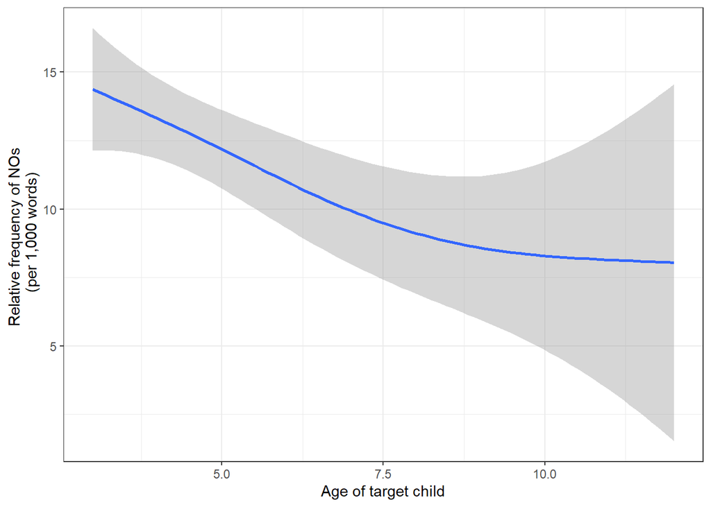

```r
no_words %>%
  dplyr::mutate(age_years_targetchild = as.numeric(age_years_targetchild)) %>%
  ggplot(aes(x = age_years_targetchild, y = freq)) +
  geom_smooth() +
  theme_bw() +
  labs(x = "Age of target child", y = "Relative frequency of NOs \n (per 1,000 words)") +
  ggsave(here::here("images", "no_words.png"), width = 6, height = 4, units = "cm")
```

## Example 2: Extracting all questions by mothers

Here, we want to extract all questions uttered by mothers. We operationalize questions as utterances containing a question mark.

```r
questions <- childes %>%
  dplyr::filter(speaker == "MOT") %>%
  dplyr::filter(stringr::str_detect(utterance, "\\?"))
# inspect data
head(questions)
```

```
##   id  files speaker                                        utterance
## 1  9 acebr1     MOT                                            Chi ?
## 2 10 acebr1     MOT                   you wan(t) (t)a hear a story ?
## 3 15 acebr1     MOT                      will you show me the moon ?
## 4 17 acebr1     MOT           Chi you don't know where the moon is ?
## 5 19 acebr1     MOT                               is that the moon ?
## 6 21 acebr1     MOT okay where's the egg that's laying on the leaf ?
##                                                                                                                 postag
## 1                                                                                                         n:prop|Chi ?
## 2                                                                 pro:per|you v|want inf|to v|hear det:art|a n|story ?
## 3                                                          mod|will pro:per|you v|show pro:obj|me det:art|the n|moon ?
## 4                            n:prop|Chi pro:per|you mod|do~neg|not v|know pro:int|where det:art|the n|moon cop|be&3S ?
## 5                                                                             cop|be&3S comp|that det:art|the n|moon ?
## 6 co|okay pro:int|where~cop|be&3S det:art|the n|egg pro:rel|that~aux|be&3S part|lay-PRESP prep|on det:art|the n|leaf ?
##   comment                                       participants age_targetchild
```

[output cut: 34 more lines]

We could now check if the rate of questions changes over time.

```r
qmot <- childes %>%
  dplyr::filter(speaker == "MOT") %>%
  dplyr::mutate(questions = ifelse(stringr::str_detect(utterance, "\\?") == T, 1,0),
                utterances = 1) %>%
  dplyr::group_by(age_years_targetchild) %>%
  dplyr::summarise(utterances = sum(utterances),
                questions = sum(questions),
                percent = round(questions/utterances*100, 2))
# inspect data
head(qmot)
```

```
## # A tibble: 6 x 4
##   age_years_targetchild utterances questions percent
##   <chr>                      <dbl>     <dbl>   <dbl>
## 1 10                          4249       926    21.8
## 2 11                           343       141    41.1
## 3 12                            56        22    39.3
## 4 3                          27209      9095    33.4
## 5 4                          45068     14492    32.2
## 6 5                          37634     10857    28.8
```

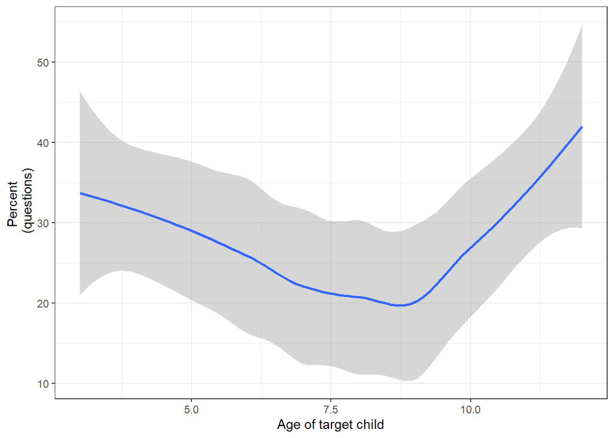

```r
qmot %>%
  dplyr::mutate(age_years_targetchild = as.numeric(age_years_targetchild)) %>%
  ggplot(aes(x = age_years_targetchild, y = percent)) +
  geom_smooth() +
  theme_bw() +
  labs(x = "Age of target child", y = "Percent \n (questions)")
```

## Example 3: Extracting aux + part by mothers

Here we want to extract all occurrences of an auxiliary plus a participle (e.g. *is swimming*) produced by mothers.

```r
auxv <- childes %>%
  dplyr::filter(speaker == "MOT") %>%
  dplyr::filter(stringr::str_detect(postag, "aux\\|\\S{1,} part\\|"))
# inspect data
head(auxv)
```

```
##    id  files speaker                                        utterance
## 1  21 acebr1     MOT okay where's the egg that's laying on the leaf ?
## 2  56 acebr1     MOT                      and here he is coming out !
## 3  68 acebr1     MOT                   looks like he's eating a lot .
## 4 202 acebr1     MOT        see the dog's getting closer to the cat .
## 5 204 acebr1     MOT              (be)cause he's getting closer [!] .
## 6 205 acebr1     MOT                       he's gonna catch the cat .
##                                                                                                                 postag
## 1 co|okay pro:int|where~cop|be&3S det:art|the n|egg pro:rel|that~aux|be&3S part|lay-PRESP prep|on det:art|the n|leaf ?
## 2                                                    coord|and adv|here pro:sub|he aux|be&3S part|come-PRESP adv|out !
## 3                                            v|look-3S conj|like pro:sub|he~aux|be&3S part|eat-PRESP det:art|a n|lot .
## 4                            v|see det:art|the n|dog~aux|be&3S part|get-PRESP adj|close-CP prep|to det:art|the n|cat .
## 5                                                      conj|because pro:sub|he~aux|be&3S part|get-PRESP adj|close-CP .
## 6                                                pro:sub|he~aux|be&3S part|go-PRESP~inf|to v|catch det:art|the n|cat .
##   comment                                       participants age_targetchild
```

[output cut: 34 more lines]

We can now extract all the particle forms from the pos-tagged utterance

```r
auxv_verbs <- auxv %>%
  dplyr::mutate(participle = gsub(".*part\\|(\\w{1,})-.*", "\\1", postag)) %>%
  dplyr::pull(participle)
head(auxv_verbs)
```

```
## [1] "lay"  "come" "eat"  "get"  "get"  "go"
```

```r
auxv_verbs_df <- auxv_verbs %>%
  as.data.frame(.)  %>%
  dplyr::rename("verb" = colnames(.)[1]) %>%
  dplyr::group_by(verb) %>%
  dplyr::summarise(freq = n()) %>%
  dplyr::arrange(-freq) %>%
  head(20)
# inspect
head(auxv_verbs_df)
```

```
## # A tibble: 6 x 2
##   verb     freq
##   <chr>   <int>
## 1 go       1927
## 2 call      308
## 3 do        243
## 4 eat       205
## 5 get       184
## 6 suppose   146
```

We can again visualize the results. In this case, we create a bar plot (see the `geom_bar`).

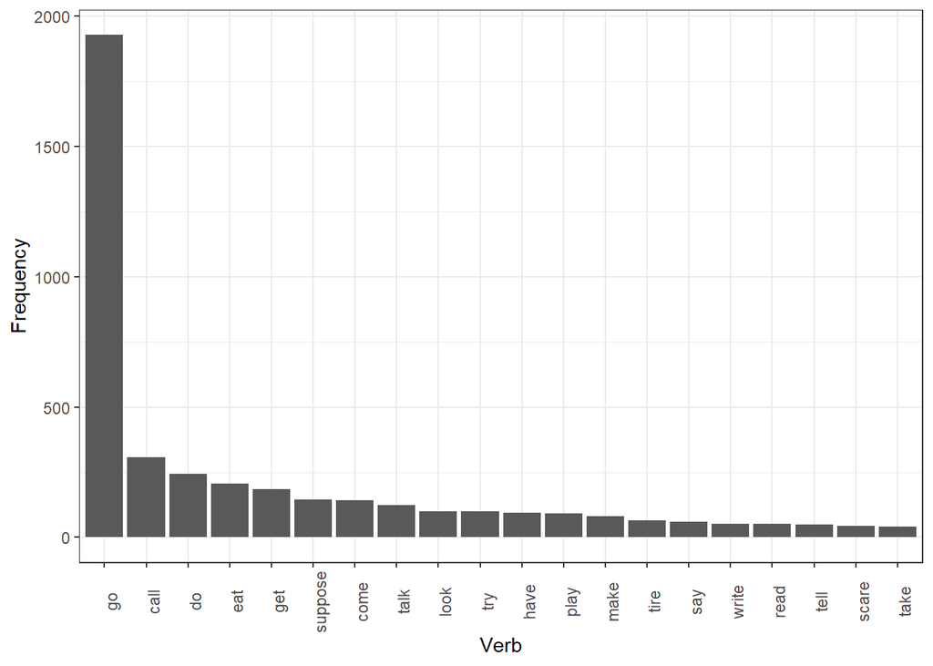

```r
auxv_verbs_df %>%
  ggplot(aes(x = reorder(verb, -freq), y = freq)) +
  geom_bar(stat = "identity") +
  theme_bw() +
  labs(x = "Verb", y = "Frequency") +
  theme(axis.text.x = element_text(angle = 90))
```

## Example 4: How many verbs do children use by age?

Here we extract all lexical verbs and words uttered by children by year and then see if the rate of verbs changes over time.

```r
nverbs <- childes %>%
  dplyr::filter(speaker == "CHI") %>%
  dplyr::mutate(nverbs = stringr::str_count(postag, "^v\\|| v\\|"),
  age_years_targetchild = as.numeric(age_years_targetchild)) %>%
  dplyr::group_by(age_years_targetchild) %>%
  dplyr::summarise(words = sum(words),
                verbs = sum(nverbs)) %>%
  dplyr::mutate(verb.word.ratio = round(verbs/words, 3))
# inspect data
nverbs
```

```
## # A tibble: 10 x 4
##    age_years_targetchild  words verbs verb.word.ratio
##                    <dbl>  <int> <int>           <dbl>
##  1                     3  57850  5424           0.094
##  2                     4 102994 10355           0.101
##  3                     5 113701 11935           0.105
##  4                     6   8901   934           0.105
##  5                     7  60751  5405           0.089
##  6                     8   5722   588           0.103
##  7                     9  47652  4739           0.099
##  8                    10  20742  2169           0.105
##  9                    11   1534   160           0.104
## 10                    12    173    13           0.075
```

We can also visualize the results to show any changes over time.

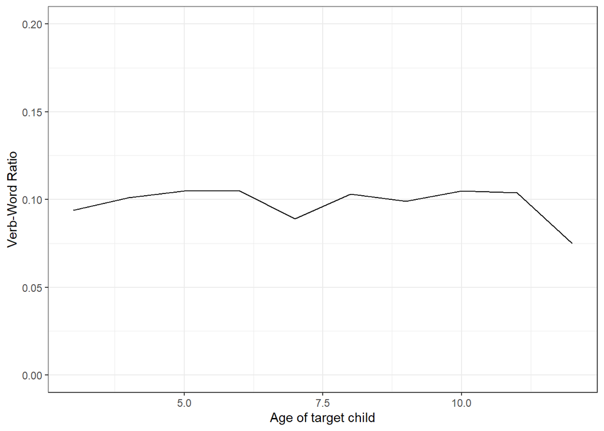

```r
nverbs %>%
  ggplot(aes(x = age_years_targetchild, y = verb.word.ratio)) +
  geom_line() +
  coord_cartesian(ylim = c(0, 0.2)) +
  theme_bw() +
  labs(x = "Age of target child", y = "Verb-Word Ratio")
```

# Saving data to your computer

To save results on your computer, you can use the `write.table` function as shown below.

```r
write.table(nverbs, here::here("tables", "nverbs.txt"), sep = "\t", row.names = F)
```

# Citation & Session Info

Schweinberger, Martin. 2021. *Working with the Child Language Data Exchange System (CHILDES) using R*. Tromsø: The Artic University of Norway. url: https://slcladal.github.io/mmws.html (Version 2021.09.07).

```
@manual{schweinberger2021mmws,
  author = {Schweinberger, Martin},
  title = {Working with the Child Language Data Exchange System (CHILDES) using R},
  note = {https://slcladal.github.io/mmws.html},
  year = {2021},
  organization = "Arctic University of Norway, AcqVA Aurora Center},
  address = {Tromsø},
  edition = {2021.09.07}
}
```

Back to top